# Generating and calculating causal models for Limpopo

Cory Whitney, Eike Luedeling

## The model

Decision-makers often wish to have a quantitative basis for their decisions. However,‘hard data’ is often missing or unattainable for many important variables, which can paralyze the decision-making processes or lead decision-makers to conclude that large research efforts are needed before a decision can be made. That is, many variables decision makers must consider cannot be precisely quantified, at least not without unreasonable effort. The major objective of (prescriptive) decision analysis is to support decision-making processes faced with this problem. Following the principles of Decision Analysis can allow us to make forecasts of decision outcomes without precise numbers, as long as probability distributions describing the possible values for all variables can be estimated.

The `decisionSupport` package implements this as a Monte Carlo simulation, which generates a large number of plausible system outcomes, based on random numbers for each input variable that are drawn from user-specified probability distributions. This approach is useful for determining whether a clearly preferable course of action can be delineated based on the present state of knowledge without the need for further information. If the distribution of predicted system outcomes does not imply a clearly preferable decision option, variables identified as carrying decision-relevant uncertainty can then be targeted by decision-supporting research.

The `mcSimulation` function from the `decisionSupport` package can be applied to conduct decision analysis (Luedeling et al. 2021). The function requires three inputs:

1. an `estimate` of the joint probability distribution of the input variables. These specify the names and probability distributions for all variables used in the decision model. These distributions aim to represent the full range of possible values for each component of the model.
2. a `model_function` that predicts decision outcomes based on the variables named in a separate data table. This R function is customized by the user to address a particular decision problem to provide the decision analysis model.
3. `numberOfModelRuns` indicating the number of times to run the model function.

These inputs are provided as arguments to the `mcSimulation` function, which conducts a Monte Carlo analysis with repeated model runs based on probability distributions for all uncertain variables. The data table and model are customized to fit the particulars of a specific decision.

### The `estimate`

To support the model building process we design an input table to store the `estimate` values. The table is stored locally as `limpopo_input_table.csv` and contains many of the basic values for the analysis. This table contains all the input variables used in the model. Their distributions are described by 90% confidence intervals, which are specified by lower (5% quantile) and upper (95% quantile) bounds, as well as the shape of the distribution. This model uses four different distributions:

1. `const` – a constant value
2. `norm` – a normal distribution
3. `tnorm_0_1` – a truncated normal distribution that can only have values between 0 and 1 (useful for probabilities; note that 0 and 1, as well as numbers outside this interval are not permitted as inputs)
4. `posnorm` – a normal distribution truncated at 0 (only positive values allowed)

For a full list of possible distributions, type `?random.estimate1d` in your R console. When specifying confidence intervals for truncated distributions, note that approximately 5% of the random values should ‘fit’ within the truncation interval on either side. If there is not enough space, the function will generate a warning (usually it will still work, but the inputs may not look like you intended them to).

### The `model_function`

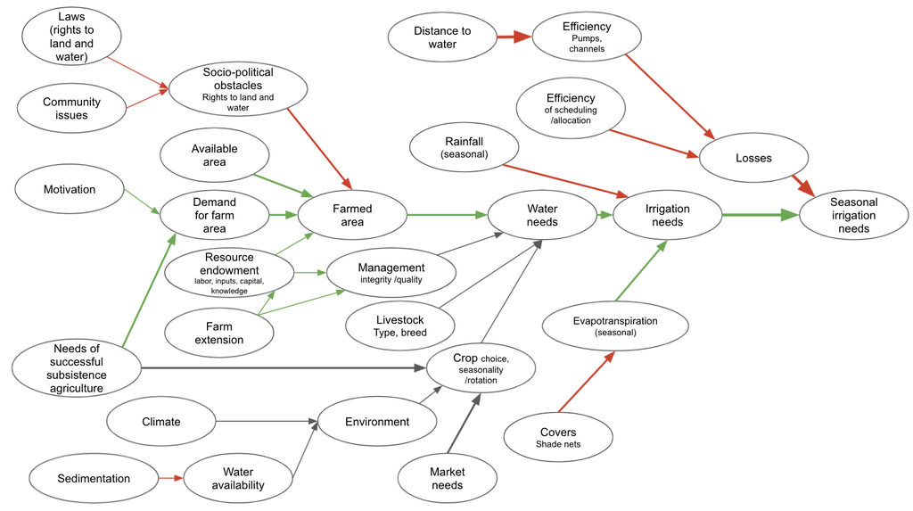

Model of the social effects of altered river flows on the sustainability of livelihoods in the Limpopo Basin

The decision model is coded as an R function which takes in the variables provided in the data table and generates a model output, such as the Net Present Value.

In the following we use of various decisionSupport functions, which use the `tidyverse` libraries (Wickham et al. 2019) including `ggplot2` (Wickham, Chang, et al. 2021), `plyr` (Wickham 2020) and `dplyr` (Wickham, François, et al. 2021) among others in the [R programming language](https://www.r-project.org/) (R Core Team 2021).

### Scenarios

The following function defines 3 scenarios:

- Scenario 1 - no eflows: This is a scenario without eflows. Farmers extract water according to their irrigation needs. Extractions are only limited by the minimum water level that allows operating the pumps.
- Scenario 2 - restricted extraction: This is an eflow scenario, in which eflows are interpreted in a purely ecological sense. Whenever eflows aren’t achieved, water extraction is curtailed. There are no measures to add water to the river in such events.
- Scenario 3 - dam releases: This is an eflow scenario, in which eflows are interpreted as encompassing the ecological as well as the smallholder irrigation requirement. In case eflows aren’t naturally met, water is released from upstream dams to ensure eflows. Extraction by smallholder farmers is restricted only by the ability to operate the pumps.

```r
limpopo_decision_function <- function(x, varnames){


# generating boundary conditions for the simulation run

# how much rainwater is available
# for now we used data from some random climate diagram on the internet
rainfall<-sapply(1:12,function(x) eval(parse(text=paste0("prec_",x))))

effective_rainfall<-sapply(rainfall,function(x) min(x,effprec_high))
effective_rainfall<-sapply(effective_rainfall,function(x) max(x,effprec_low))


# we'll compute crop water needs based on ET0 (computed based on the Hargreaves
# Samani equation, as implemented in the Evapotranspiration package). Input
# temperature data comes from the NASAPOWER dataset (accessed through the
# nasapower package)
# The data will be based on scenarios that represent conditions during real
# years in the past
# To get from ET0 to crop water use, we need to multiply ET0 with a crop
# coefficient (kc), which is estimated for each month

ET0<-sapply(1:12,function(x) eval(parse(text=paste0("ET0_",x)))) # in mm

kc<-sapply(1:12,function(x) eval(parse(text=paste0("kc_",x)))) # in mm

cropwat_need<-ET0*kc # in mm

irrigation_need<-cropwat_need-effective_rainfall # in mm


# define river flow and eflow for each month ####
# Base river flow data from 1920 to 2010, Letaba River at EWR site EWR4 (Letaba Ranch upstream Little Letaba confluence)
pre_livestock_river_flow<-sapply(1:12,function(x) eval(parse(text=paste0("river_flow_",x)))) # in m3 / month
eflow<-sapply(1:12,function(x) eval(parse(text=paste0("eflow_",x)))) # in m3 / month

# watering livestock
# assuming that this is more or less stable throughout the year, but varies a bit
livestock_water_needs<-vv(livestock_water_need,var_CV,12)

# assuming that the eflows aren't affecting ability to water livestock and that there's always enough
# water for all the livestock
river_flow<-pre_livestock_river_flow-livestock_water_needs

# calculating the farmed area

demand_for_farm_area<-n_subsistence_farmers*necessary_farm_size_per_household

farmed_area<-min(available_area, demand_for_farm_area)*(1-unused_sociopolit)


total_cropwater_need<-cropwat_need*farmed_area*10 # total water need in m3 (the 10 is the mm to m3/ha conversion)
total_effective_rainfall<-effective_rainfall*farmed_area*10 # total effective rainfall

# total irrigation need
total_irrigation_need<-total_cropwater_need-total_effective_rainfall # in m3

# water losses are calculated from the efficiency of the pumps and the water allocation
efficiency_pumps<-vv(effi_pump,var_CV,12)
efficiency_irrig_scheduling<-vv(effi_sched,var_CV,12)
efficiency_pumps<-sapply(efficiency_pumps, function(x)  min(x,1))
efficiency_pumps<-sapply(efficiency_pumps, function(x)  max(x,0))
efficiency_irrig_scheduling<-sapply(efficiency_irrig_scheduling, function(x)  min(x,1))
efficiency_irrig_scheduling<-sapply(efficiency_irrig_scheduling, function(x)  max(x,0))

water_losses_share<-(1-efficiency_pumps*efficiency_irrig_scheduling)

irrigation_water_need<-total_irrigation_need/(1-water_losses_share)

# eflow scenario 1 - no eflows

scen1_usable_river_flow<-sapply(1:12,function(x) max(0,river_flow[x]-minimum_flow_to_operate_pumps))

# eflow scenario 2 - eflows as a limit to extraction only

# eflows are to be ensured whenever there is more water in the river than the eflow
# requirement would mandate, i.e. farmers aren't allowed to extract water beyond
# the eflow requirement.
# no measures are taken to ensure that eflows are maintained at times when
# the present flow is below the eflow requirement.

scen2_usable_river_flow<-sapply(1:12,function(x) max(0,river_flow[x]-max(eflow[x],minimum_flow_to_operate_pumps)))

# eflow scenario 3 - eflows are assured by dam releases

# whenever the present flow is below the eflow requirement, water is released
# from an upstream dam to ensure that the eflows are met.

adj_river_flow <- sapply(1:12, function(x)
  max(river_flow[x], eflow[x]))

required_dam_release <- adj_river_flow - river_flow

scen3_usable_river_flow <-
  sapply(1:12, function(x)
    max(0, adj_river_flow[x] - minimum_flow_to_operate_pumps))

# how much water gets extracted from the river

scen1_extracted_river_water <-
  sapply(1:12, function(x)
    min(scen1_usable_river_flow[x], irrigation_water_need[x]))
scen2_extracted_river_water <-
  sapply(1:12, function(x)
    min(scen2_usable_river_flow[x], irrigation_water_need[x]))
scen3_extracted_river_water <-
  sapply(1:12, function(x)
    min(scen3_usable_river_flow[x], irrigation_water_need[x]))

# calculate damage to crop production due to lack of irrigation water
scen1_water_shortfall <-
  sapply(1:12, function (x)
    max(0, irrigation_water_need[x] - scen1_extracted_river_water[x]))
scen2_water_shortfall <-
  sapply(1:12, function (x)
    max(0, irrigation_water_need[x] - scen2_extracted_river_water[x]))
scen3_water_shortfall <-
  sapply(1:12, function (x)
    max(0, irrigation_water_need[x] - scen3_extracted_river_water[x]))

scen1_irrigation_shortfall<-scen1_water_shortfall*(1-water_losses_share)
scen2_irrigation_shortfall<-scen2_water_shortfall*(1-water_losses_share)
scen3_irrigation_shortfall<-scen3_water_shortfall*(1-water_losses_share)

scen1_crop_water_gap<-scen1_irrigation_shortfall/(cropwat_need*farmed_area*10)
scen2_crop_water_gap<-scen2_irrigation_shortfall/(cropwat_need*farmed_area*10)
scen3_crop_water_gap<-scen3_irrigation_shortfall/(cropwat_need*farmed_area*10)


# calculate how much water is left after farmers extracted water
scen1_river_flow_downstream<-river_flow-scen1_extracted_river_water
scen2_river_flow_downstream<-river_flow-scen2_extracted_river_water
scen3_river_flow_downstream<-adj_river_flow-scen3_extracted_river_water


## what happens if we can't meet the water needs?


return(list(scen1_downstream_river_flow=scen1_river_flow_downstream,
            scen2_downstream_river_flow=scen2_river_flow_downstream,
            scen3_downstream_river_flow=scen3_river_flow_downstream,
            scen3_dam_release=required_dam_release,
            Downstream_difference_2_vs_1=scen2_river_flow_downstream-scen1_river_flow_downstream,
            Downstream_difference_3_vs_1=scen3_river_flow_downstream-scen1_river_flow_downstream,
            scen1_crop_water_gap=scen1_crop_water_gap,
            scen2_crop_water_gap=scen2_crop_water_gap,
            scen3_crop_water_gap=scen3_crop_water_gap,
            Crop_water_gap_difference_2_vs_1=scen2_crop_water_gap-scen1_crop_water_gap,
            Crop_water_gap_difference_3_vs_1=scen3_crop_water_gap-scen1_crop_water_gap,
            Mean_Crop_water_gap_difference_2_vs_1=mean(scen2_crop_water_gap-scen1_crop_water_gap),
            Mean_Crop_water_gap_difference_3_vs_1=mean(scen3_crop_water_gap-scen1_crop_water_gap)))

}
```

#### Perform a Monte Carlo simulation with scenarios

Using the model function above, we can perform a Monte Carlo simulation with the `mcSimulation()` function from `decisionSupport`. This function generates distributions of all variables in the input table as well as the specified model outputs (see `return()` function above) by calculating random draws in our defined `limpopo_decision_function()`. Make sure that all the variables in the input table are included in the model (erroneous variables listed there can cause issues with some of the post-hoc analyses).

The `numberOfModelRuns` argument is an integer indicating the number of model runs for the Monte Carlo simulation. Unless the model function is very complex, 10,000 runs is a reasonable choice (for complex models, 10,000 model runs can take a while, so especially when the model is still under development, it often makes sense to use a lower number).

```r
library(Evapotranspiration)
data("constants")

library(nasapower)

ag_d <- get_power(
  community = "ag",
  lonlat = c(31.08,-23.7),
  pars = c("T2M_MAX", "T2M_MIN", "PRECTOTCORR"),
  dates = c("1981-01-01", "2020-12-31"),
  temporal_api = "daily"
)

years<-1981:2009

colnames(ag_d)[c(3:5, 8, 9, 10)] <-
  c("Year", "Month", "Day", "Tmax", "Tmin", "Precipitation")

Inputs <- ReadInputs(c("Tmin", "Tmax"), ag_d, stopmissing = c(50, 50, 50))
```

```
#> The maximum acceptable percentage of date indices is 50 %
#> The maximum acceptable percentage of missing data is 50 %
#> The maximum acceptable percentage of continuous missing data is 50 %
```

```r
ET <-
  ET.HargreavesSamani(
    Inputs,
    constants,
    ts = "daily",
    message = "yes",
    AdditionalStats = "yes",
    save.csv = "no"
  )
```

```
#> Hargreaves-Samani Reference Crop ET
#> Evaporative surface: reference crop
#> Timestep: daily
#> Units: mm
#> Time duration: 1981-01-01 to 2020-12-31
#> 14610 ET estimates obtained
#> Basic stats
#> Mean: 4.94
#> Max: 30.45
#> Min: 1.35
```

```r
ETdata <- data.frame(year = years)
ETdata[, month.abb[1:12]] <- NA
for (yyyy in years)
  ETdata[which(ETdata$year == yyyy), 2:13] <-
  ET$ET.Monthly[as.character(yyyy + 0:11 / 12)]

rain <-
  aggregate(ag_d$Precipitation,
            by = list(ag_d$Year, ag_d$Month),
            FUN = sum)
raindata <- data.frame(year = years)
raindata[, month.abb[1:12]] <- NA
for (yyyy in years)
  raindata[which(raindata[, 1] == yyyy), 2:13] <-
  rain[which(rain[, 1] == yyyy), 3]


scenario_variables <-
  c(paste0("river_flow_", 1:12),
    paste0("ET0_", 1:12),
    paste0("prec_", 1:12),
    paste0("eflow_", 1:12))

Scenarios <- data.frame(Variable = scenario_variables, param = "both")

eflows<-read.csv("data/Letaba_eflows_exceedence_m3_per_s.csv",fileEncoding="UTF-8-BOM")
eflowsort <-
  eflows[, c(1, order(unlist(sapply(colnames(eflows)[2:13], function(x)
    which(month.abb[1:12] == x)))) + 1)]
eflow_exceedance<-eflowsort[which(eflowsort$Exceedence == 80),]
eflow_per_month<-eflow_exceedance[2:13]*c(31,28,31,30,31,30,31,31,30,31,30,31)*3600*24


present_flows<-read.csv("data/Letaba_modelled_present_flows_m3_per_s.csv",fileEncoding="UTF-8-BOM")
presentflowsort <-
  present_flows[, c(1, order(unlist(sapply(colnames(present_flows)[2:13], function(x)
    which(month.abb[1:12] == x)))) + 1)]
presentflow_permonth<-data.frame(cbind(presentflowsort[,1],t(t(presentflowsort[,2:13])*c(31,28,31,30,31,30,31,31,30,31,30,31)*3600*24)))
colnames(presentflow_permonth)[1]<-"Year"

# The hydrological year in the input file starts in October and runs until September. We're assuming here that the year given for each year corresponds to the first calendar year of this period.

presentflow_permonth[2:nrow(presentflow_permonth),month.abb[1:9]]<-
  presentflow_permonth[1:(nrow(presentflow_permonth)-1),month.abb[1:9]]

presentflow_permonth[1,month.abb[1:9]]<-NA

for (yyyy in years)
{
  Scenarios[, paste0("y_", yyyy)] <- NA
  for (mm in 1:12)
  {
    Scenarios[which(Scenarios$Variable == paste0("ET0_", mm)), paste0("y_", yyyy)] <-
      ETdata[which(ETdata$year == yyyy), 1 + mm]
    Scenarios[which(Scenarios$Variable == paste0("prec_", mm)), paste0("y_", yyyy)] <-
      raindata[which(raindata$year == yyyy), 1 + mm]
    Scenarios[which(Scenarios$Variable == paste0("river_flow_", mm)), paste0("y_", yyyy)] <-
      presentflow_permonth[which(presentflow_permonth$Year == yyyy), 1 + mm]
    Scenarios[which(Scenarios$Variable == paste0("eflow_", mm)), paste0("y_", yyyy)] <-
      eflow_per_month[mm]
  }
}

#natural flows not used so far
natural_flows<-read.csv("data/Letaba_modelled_natural_flows_m3_per_s.csv",fileEncoding="UTF-8-BOM")





write.csv(Scenarios, "data/scenarios_1980_2020.csv", row.names = FALSE)
```

```r
mcSimulation_results <-
  scenario_mc(
    base_estimate = decisionSupport::estimate_read_csv("data/limpopo_input_table.csv"),
    scenarios = read.csv("data/scenarios_1980_2020.csv", fileEncoding =
                           "UTF-8-BOM"),
    model_function = limpopo_decision_function,
    numberOfModelRuns = 2e2,
    #run 1,000 times
    functionSyntax = "plainNames"
  )
```

#### Plot Net Present Value (NPV) distributions

Here’s the difference between the crop water gap in eflow scenario 2 vs. the baseline (no eflows)

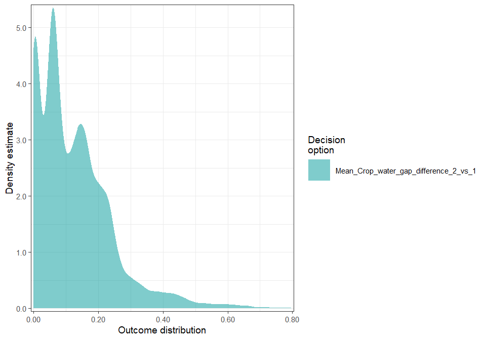

```r
decisionSupport::plot_distributions(mcSimulation_object = mcSimulation_results,
                                    vars = c("Mean_Crop_water_gap_difference_2_vs_1"),
                                    method = 'smooth_simple_overlay',
                                    base_size = 7)
```

In short, an eflow scenario that simply curtails extraction but doesn’t alleviate sub-eflow flows, is likely to cause considerable irrigation water shortages.

Here’s the difference between the crop water gap in eflow scenario 3 (incl. dam releases) vs. the baseline (no eflows)

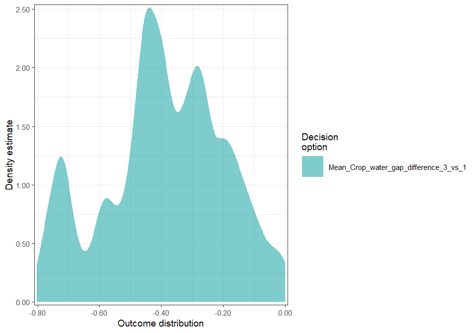

```r
decisionSupport::plot_distributions(mcSimulation_object = mcSimulation_results,
                                    vars = c("Mean_Crop_water_gap_difference_3_vs_1"),
                                    method = 'smooth_simple_overlay',
                                    base_size = 7)
```

An eflow scenario that includes dam releases to ensure eflows (scenario 3) benefits farmers by effectively precluding irrigation water shortfalls.

#### Flow analysis

Here we plot the distribution of downstream flow difference over the entire simulated year. For this we use the `plot_cashflow()` function, which uses the `Downstream_difference` output from the `mcSimulation()` function to show the difference in downstream river flow over time.

First for scenario 2 vs. the no-eflow baseline:

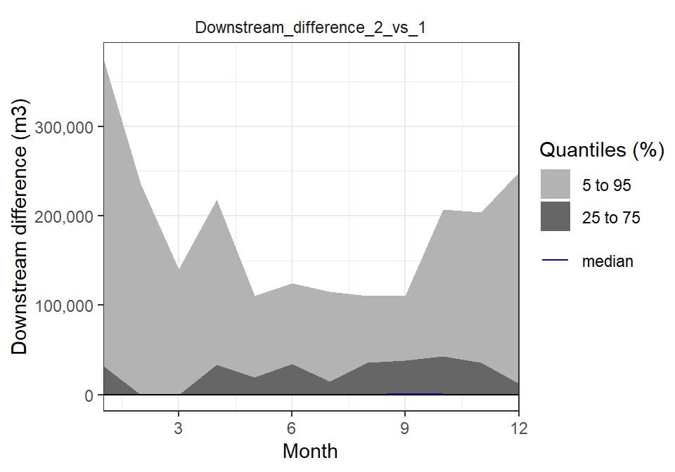

```r
plot_cashflow(mcSimulation_object = mcSimulation_results,
              cashflow_var_name = "Downstream_difference_2_vs_1",
              y_axis_name = "Downstream difference (m3)",
              x_axis_name = "Month")
```

Now for scenario 3 vs. the no-eflow baseline:

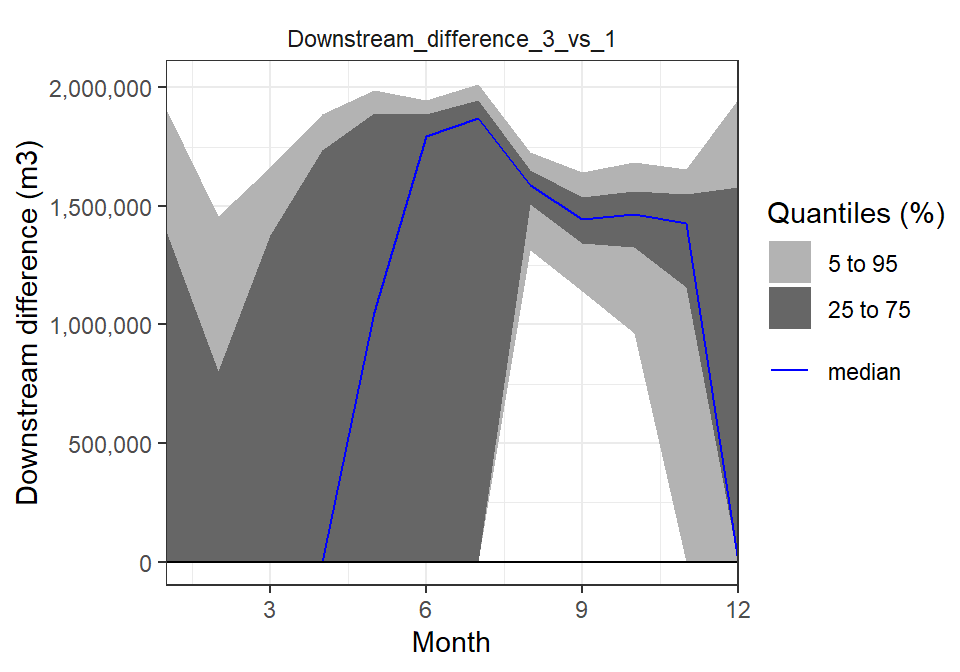

```r
plot_cashflow(mcSimulation_object = mcSimulation_results,
              cashflow_var_name = "Downstream_difference_3_vs_1",
              y_axis_name = "Downstream difference (m3)",
              x_axis_name = "Month")
```

And these are the dam releases required to maintain scenario 3:

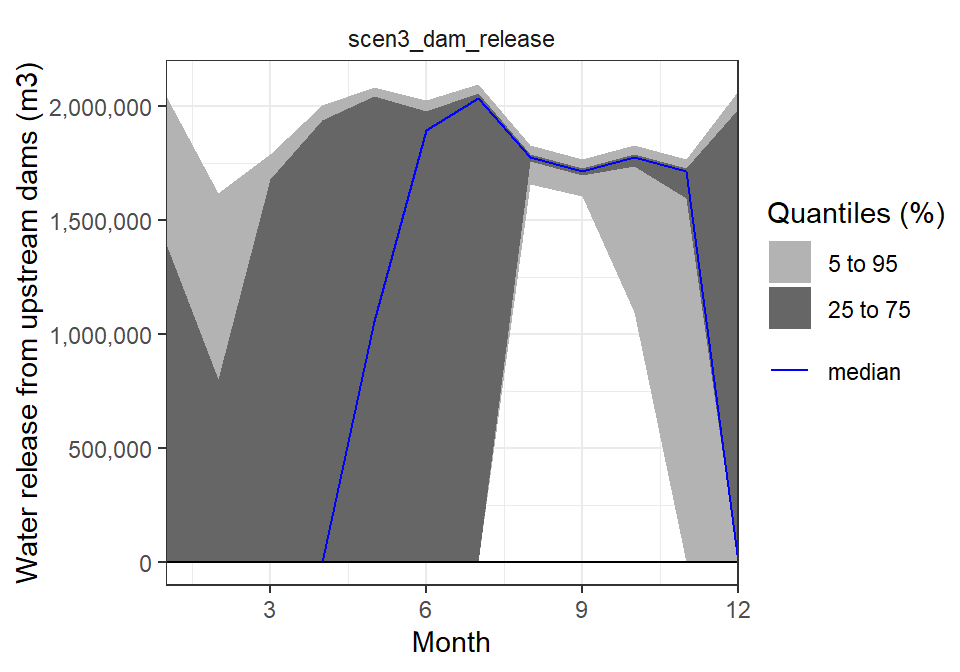

```r
plot_cashflow(mcSimulation_object = mcSimulation_results,
              cashflow_var_name = "scen3_dam_release",
              y_axis_name = "Water release from upstream dams (m3)",
              x_axis_name = "Month")
```

Here a similar plot of `Crop_water_gap_difference` to show the crop water gap over time.

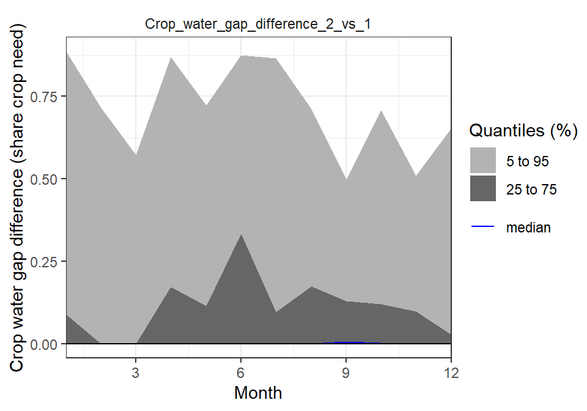

```r
plot_cashflow(mcSimulation_object = mcSimulation_results,
              cashflow_var_name = "Crop_water_gap_difference_2_vs_1",
              y_axis_name = "Crop water gap difference (share crop need)",
              x_axis_name = "Month")
```

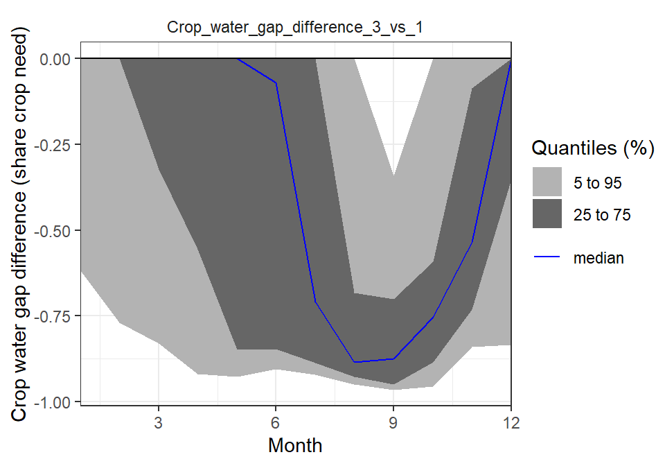

```r
plot_cashflow(mcSimulation_object = mcSimulation_results,
              cashflow_var_name = "Crop_water_gap_difference_3_vs_1",
              y_axis_name = "Crop water gap difference (share crop need)",
              x_axis_name = "Month")
```

#### Projection to Latent Structures (PLS) analysis

Projection to Latent Structures (PLS), also sometimes known as Partial Least Squares regression is a multivariate statistical technique that can deal with multiple colinear dependent and independent variables (Wold, Sjöström, and Eriksson 2001). It can be used as another means to assess the outcomes of a Monte Carlo model. Read more in [‘A Simple Explanation of Partial Least Squares’ by Kee Siong Ng](http://users.cecs.anu.edu.au/~kee/pls.pdf).

Variable Importance in Projection (VIP) scores estimate the importance of each variable in the projection used in a PLS mode. VIP is a parameter used for calculating the cumulative measure of the influence of individual $X$-variables on the model. For a given PLS dimension, $a$, the squared PLS weight $(Wa)2$ of that term is multiplied by the explained sum of squares ($SS$) of that $PLS$ dimension; and the value obtained is then divided by the total explained $SS$ by the PLS model and multiplied by the number of terms in the model. The final $VIP$ is the square root of that number.

$VIP_{PLS} = K\times (\frac{[\sum_{a=1}^{A}(W_{a}^{2} \times SSY_{comp,a})]}{SSY_{cum}})$

The VIP is a weighted combination overall components of the squared PLS weights ($Wa$), where $SSY_{comp,a}$ is the sum of squares of $Y$ explained by component $a$, $A$ is the total number of components, and $K$ is the total number of variables. The average VIP is equal to 1 because the $SS$ of all VIP values is equal to the number of variables in $X$. A variable with a VIP Score close to or greater than 1 (one) can be considered important. The input is a PLS model and the output is a set of column vectors equal in length to the number of variables included in the model. See Galindo-Prieto, Eriksson, and Trygg (2014) for a detailed description of variations of VIP analysis.

```r
mcSimulation_pls<-mcSimulation_results
mcSimulation_pls$x<-mcSimulation_pls$x[, !names(mcSimulation_pls$x) == "Scenario"]

pls_result <- plsr.mcSimulation(object = mcSimulation_pls,
                  resultName = "Mean_Crop_water_gap_difference_2_vs_1", ncomp = 1)
```

Here we import the input table again to replace the labels for the variables on the y-axis. The input table can include a `label` and `variable` column. The standard labels (from the `variable` column) are usually computer readable and not very nice for a plot. The `plot_pls()` function uses the text in the `label` column as replacement for the default text in the `variable` column.

Here’s the plot for a PLS analysis for the outcome variable Mean_Crop_water_gap_difference_2_vs_1:

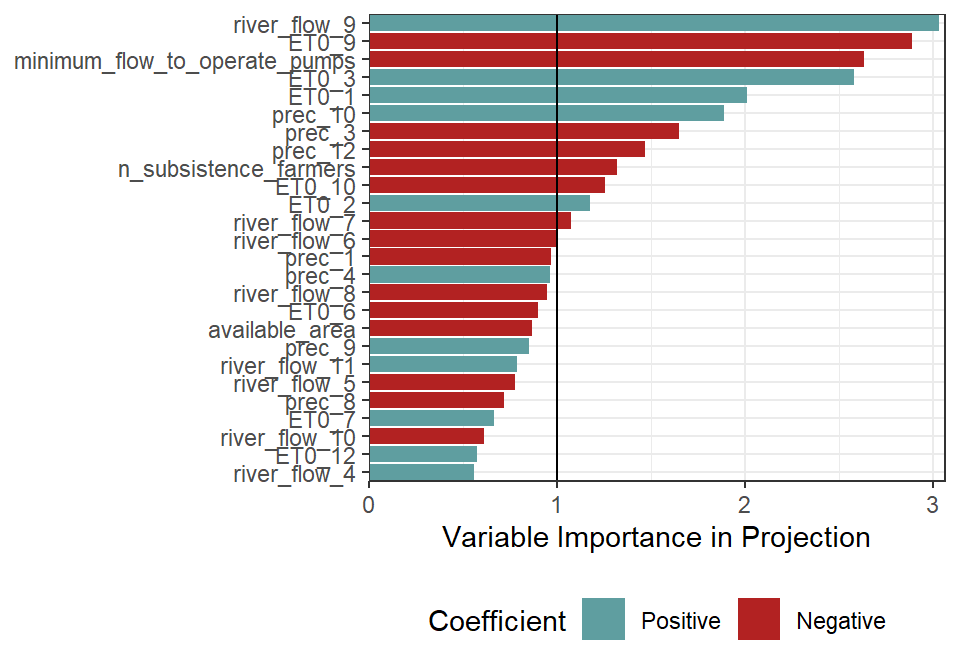

```r
input_table <- read.csv("data/limpopo_input_table.csv")

plot_pls(pls_result, input_table = input_table, threshold = 0.5)
```

Here’s the plot for a PLS analysis for the outcome variable Mean_Crop_water_gap_difference_3_vs_1:

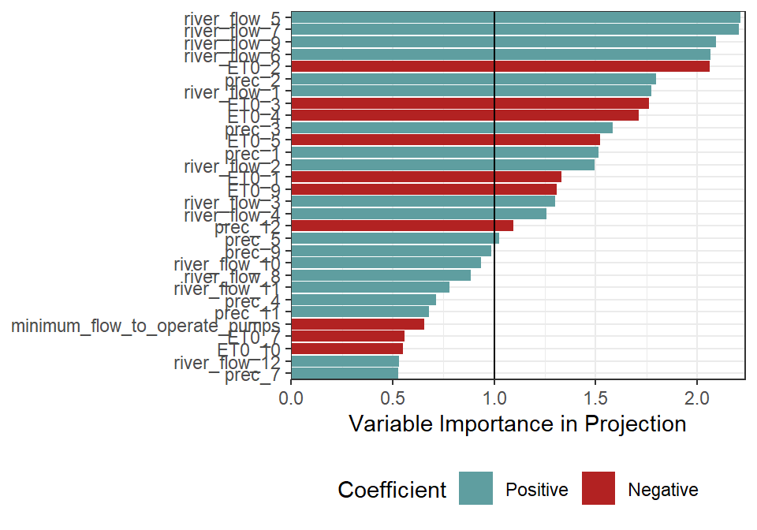

```r
input_table <- read.csv("data/limpopo_input_table.csv")

pls_result <- plsr.mcSimulation(object = mcSimulation_pls,
                  resultName = "Mean_Crop_water_gap_difference_3_vs_1", ncomp = 1)

plot_pls(pls_result, input_table = input_table, threshold = 0.5)
```

### Addendum

The objective of the procedures used in the `decisionSupport` package is to make it easier for analysts to produce decision-relevant information that adequately reflects the imperfect nature of the information we usually have. Adding probabilistic elements to a simulation adds substantial value to an analysis. Mostly, it avoids making spurious assumptions, replacing uncertainty with ‘best bets’ and producing results that do not reflect the knowledge limitations that make decision-making so challenging. More information on all this is contained in the [decisionSupport manual](https://cran.r-project.org/web/packages/decisionSupport/decisionSupport.pdf), especially under `welfareDecisionAnalysis`.

### References

Galindo-Prieto, Beatriz, Lennart Eriksson, and Johan Trygg. 2014. “Variable Influence on Projection (VIP) for Orthogonal Projections to Latent Structures (OPLS): Variable Influence on Projection for OPLS.” *Journal of Chemometrics* 28 (8): 623–32. https://doi.org/10.1002/cem.2627.

Lanzanova, Denis, Cory Whitney, Keith Shepherd, and Eike Luedeling. 2019. “Improving Development Efficiency Through Decision Analysis: Reservoir Protection in Burkina Faso.” *Environmental Modelling & Software* 115 (May): 164–75. https://doi.org/10.1016/j.envsoft.2019.01.016.

Luedeling, Eike, Lutz Goehring, Katja Schiffers, Cory Whitney, and Eduardo Fernandez. 2021. *decisionSupport: Quantitative Support of Decision Making Under Uncertainty*. http://www.worldagroforestry.org/.

Luedeling, Eike, and Keith Shepherd. 2016. “Decision-Focused Agricultural Research.” *Solutions* 7 (5): 46–54. https://doi.org/https://www.thesolutionsjournal.com/article/decision-focused-agricultural-research/.

R Core Team. 2021. *R: A Language and Environment for Statistical Computing*. Vienna, Austria: R Foundation for Statistical Computing. https://www.R-project.org/.

Wickham, Hadley. 2020. *Plyr: Tools for Splitting, Applying and Combining Data*. https://CRAN.R-project.org/package=plyr.

Wickham, Hadley, Mara Averick, Jennifer Bryan, Winston Chang, Lucy D’Agostino McGowan, Romain François, Garrett Grolemund, et al. 2019. “Welcome to the tidyverse.” *Journal of Open Source Software* 4 (43): 1686. https://doi.org/10.21105/joss.01686.

Wickham, Hadley, Winston Chang, Lionel Henry, Thomas Lin Pedersen, Kohske Takahashi, Claus Wilke, Kara Woo, Hiroaki Yutani, and Dewey Dunnington. 2021. *Ggplot2: Create Elegant Data Visualisations Using the Grammar of Graphics*. https://CRAN.R-project.org/package=ggplot2.

Wickham, Hadley, Romain François, Lionel Henry, and Kirill Müller. 2021. *Dplyr: A Grammar of Data Manipulation*. https://CRAN.R-project.org/package=dplyr.

Wold, Svante, Michael Sjöström, and Lennart Eriksson. 2001. “PLS-Regression: A Basic Tool of Chemometrics.” *Chemometrics and Intelligent Laboratory Systems*, PLS Methods, 58 (2): 109–30. https://doi.org/10.1016/S0169-7439(01)00155-1.